# PROJECT_8_(2)

## **Project Description – Image classification using CNNs in Keras**

## Context:

Can you differentiate a weed from a crop seedling?The ability to do so effectively can mean better crop yields and better stewardship of the environment.The Aarhus University Signal Processing group, in collaboration with University of Southern Denmark, has recently released a dataset containing images of unique plants belonging to 12 species at several growth stages.

### Data Description:

We are provided with a dataset of images of plant seedlings at various stages of growth. Each image has a filename that is its unique id. The dataset comprises 12 plant species. The goal of the project is to create a classifier capable of determining a plant's species from a photo.

### Dataset:

The data file names are:

- images.npy
- Label.csv

### Objective:

To build a convolution neural network that is capable of determining a plant's species from a photo

```python
from google.colab import drive
drive.mount('/content/drive')
```

## Importing the libraries

```python
# To help with reading and manipulation of data
import pandas as pd
import numpy as np
pd.set_option('display.max_columns',None)#removes the limit of displayed columns
pd.set_option('display.max_rows',None)# removes the limit of displayed rows

# To help with data visualisation
import seaborn as sns
import matplotlib.pyplot as plt

# To split the data to train and test
from sklearn.model_selection import train_test_split

# To perform Label encoding
from sklearn import preprocessing
from sklearn.preprocessing import LabelBinarizer

# for neural network model building and tuning
import cv2 # this is an important module to get imported which may even cause issues while reading the data if not used
import os
import tensorflow as tf
import keras
from keras import layers
from tensorflow.keras.models import Sequential, Model #sequential api for sequential model
from tensorflow.keras.layers import Conv2D, MaxPooling2D, BatchNormalization, Activation, Input, LeakyReLU,Activation
from tensorflow.keras import backend as K
from tensorflow.keras.utils import to_categorical #to perform one-hot encoding
from tensorflow.keras.layers import Dense, Dropout, Flatten, Conv2D, MaxPool2D #importing different layers
from tensorflow.keras.optimizers import RMSprop,Adam #optimizers for optimizing the model
from tensorflow.keras.callbacks import EarlyStopping  #regularization method to prevent the overfitting
from tensorflow.keras.callbacks import ModelCheckpoint #to save model at checkpoints
from tensorflow.keras import losses, optimizers
from keras.preprocessing.image import ImageDataGenerator


# To evaluate the models and create confusion matrix
from sklearn.metrics import accuracy_score, confusion_matrix
import itertools

#To suppress warnings
import warnings
warnings.filterwarnings("ignore")

seed= 7
```

### Let's load the data to work with

```python
x=np.load('/content/drive/My Drive/images.npy')#loading the images
y=pd.read_csv('/content/drive/My Drive/Labels.csv')#loading the images labels
```

```python
x.shape # To check the shape of the image data
```

```
(4750, 128, 128, 3)
```

We have 4,750 colour(RGB) images of 128 by 128 pixels each in the data set

```python
y.shape #To check the shape of the labels data
```

```
(4750, 1)
```

There are 4,750 rows and 1 column in the labels dataset. This correspond with the number of images(4750) as well. Therefore, each label row index refers to the corresponding index in the image data.

```python
x #To print the np arrays of the images
```

[output not shown]

[output cut: 252 more lines]

[output not shown]

It appears the images are mixtures of colours.

```python
y #To display the labels data
```

|  | Label |
| --- | --- |
| 0 | Small-flowered Cranesbill |
| 1 | Small-flowered Cranesbill |
| 2 | Small-flowered Cranesbill |
| 3 | Small-flowered Cranesbill |
| 4 | Small-flowered Cranesbill |
| 5 | Small-flowered Cranesbill |
| 6 | Small-flowered Cranesbill |
| 7 | Small-flowered Cranesbill |
| 8 | Small-flowered Cranesbill |
| 9 | Small-flowered Cranesbill |
| 10 | Small-flowered Cranesbill |
| 11 | Small-flowered Cranesbill |
| 12 | Small-flowered Cranesbill |
| 13 | Small-flowered Cranesbill |
| 14 | Small-flowered Cranesbill |
| 15 | Small-flowered Cranesbill |
| 16 | Small-flowered Cranesbill |
| 17 | Small-flowered Cranesbill |
| 18 | Small-flowered Cranesbill |
| 19 | Small-flowered Cranesbill |
| 20 | Small-flowered Cranesbill |
| 21 | Small-flowered Cranesbill |
| 22 | Small-flowered Cranesbill |
| 23 | Small-flowered Cranesbill |
| 24 | Small-flowered Cranesbill |
| 25 | Small-flowered Cranesbill |
| 26 | Small-flowered Cranesbill |
| 27 | Small-flowered Cranesbill |
| 28 | Small-flowered Cranesbill |
| 29 | Small-flowered Cranesbill |

[output cut: 4720 more lines]

The display of the Labels shown above makes it clear that the images are arranged in groups as there is no mixtures of the labels at all. The knowledge of this label indexes will be helpful in plotting the images a lot.

```python
y.Label.unique() #To show the unique values in the Label column
```

```
array(['Small-flowered Cranesbill', 'Fat Hen', 'Shepherds Purse',
       'Common wheat', 'Common Chickweed', 'Charlock', 'Cleavers',
       'Scentless Mayweed', 'Sugar beet', 'Maize', 'Black-grass',
       'Loose Silky-bent'], dtype=object)
```

It is obvious there are 12 unique plants species in the datasets. Let's check the frequencies of these names below

```python
y.Label.value_counts() #To see number of images in each label
```

```
Loose Silky-bent             654
Common Chickweed             611
Scentless Mayweed            516
Small-flowered Cranesbill    496
Fat Hen                      475
Charlock                     390
Sugar beet                   385
Cleavers                     287
Black-grass                  263
Shepherds Purse              231
Common wheat                 221
Maize                        221
Name: Label, dtype: int64
```

Loose Silky-bent has the highest number of images in the data set while Common wheat and Maize are jointly the lowest in number among the plants in the data set. This is an imbalanced data and models tend to have bias towards the dorminant classes. Undersampling or oversampling may help to correct such bias. However, we will pass the data the way it is into our model in this project.

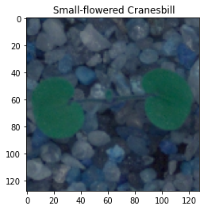

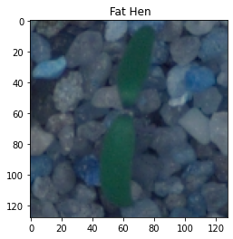

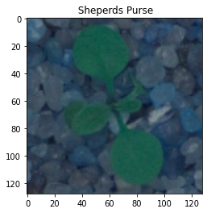

[figure not shown]

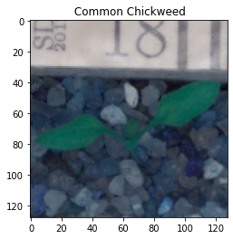

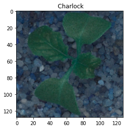

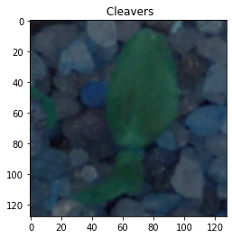

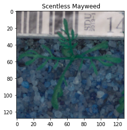

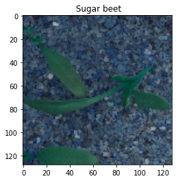

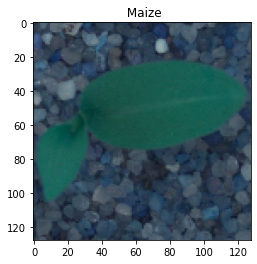

[figure not shown]

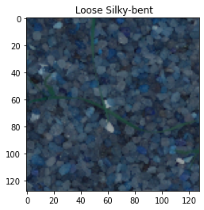

```python
#Let's plot the sample image of each plant specie in the data set
def images(data, title):
  img = plt.imshow(data)
  plt.title(f' {title}')
  plt.show()
SFC = images(x[0], 'Small-flowered Cranesbill')
FH = images(x[496], 'Fat Hen')
SP = images(x[971], 'Sheperds Purse')
CW = images(x[1202], 'Common wheat')
CC = images(x[1423], 'Common Chickweed')
CH = images(x[2034], 'Charlock')
CL = images(x[2424], 'Cleavers')
SM = images(x[2711], 'Scentless Mayweed')
SB = images(x[3227], 'Sugar beet')
MZ = images(x[3612], 'Maize')
BG = images(x[3833], 'Black-grass')
LSB = images(x[4096], 'Loose Silky-bent')
```

The images above reveal the various leaves shapes and structures of each plant specie in the data set. It can be observed that the leaf shapes and structure are the major differenciating factors among the plant species in the data. Proper classification of these plant species by our model will depend on how well these differenciating factors are learnt.

## Exploratory Data Analysis

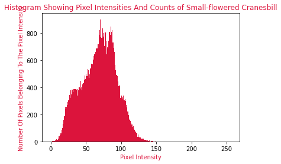

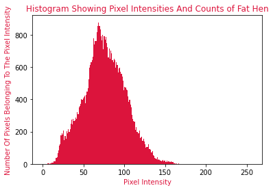

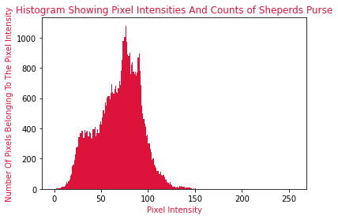

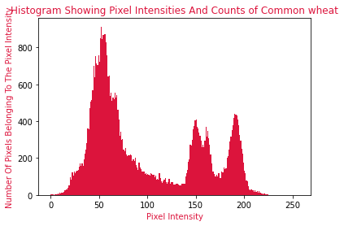

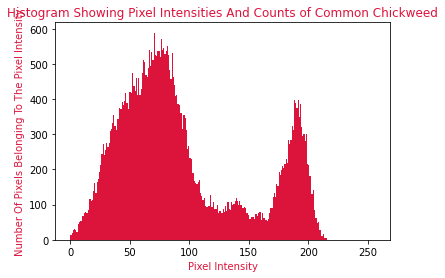

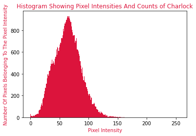

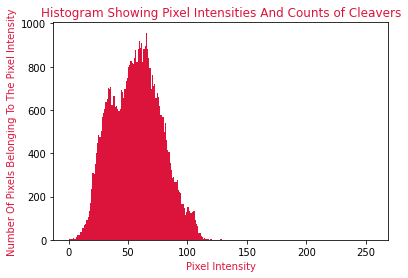

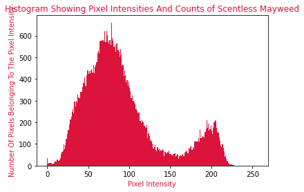

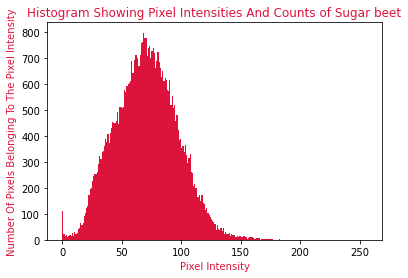

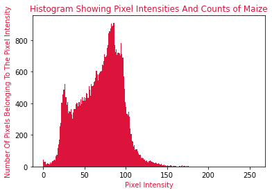

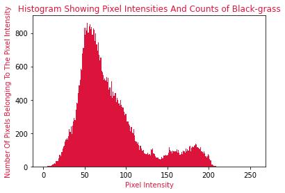

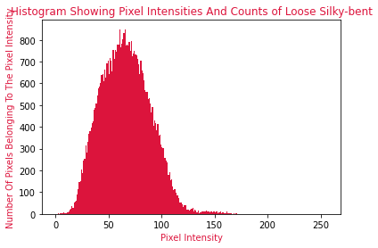

```python
#Let's plot the pixel intensity histogram of image of a sample from each plant specie in the data set
def images_int(data, title):
  plt.hist(data.ravel(), bins=256, range=[0, 256], color='crimson')
  plt.title(f'Histogram Showing Pixel Intensities And Counts of {title}', color='crimson')
  plt.ylabel("Number Of Pixels Belonging To The Pixel Intensity", color="crimson")
  plt.xlabel("Pixel Intensity", color="crimson")
  plt.show()
SFC = images_int(x[0], 'Small-flowered Cranesbill')
FH = images_int(x[496], 'Fat Hen')
SP = images_int(x[971], 'Sheperds Purse')
CW = images_int(x[1202], 'Common wheat')
CC = images_int(x[1423], 'Common Chickweed')
CH = images_int(x[2034], 'Charlock')
CL = images_int(x[2424], 'Cleavers')
SM = images_int(x[2711], 'Scentless Mayweed')
SB = images_int(x[3227], 'Sugar beet')
MZ = images_int(x[3612], 'Maize')
BG = images_int(x[3833], 'Black-grass')
LSB = images_int(x[4096], 'Loose Silky-bent')
```

The pixel intensity histograms above confirm that most of the plants sampled have concentration of colours to the left side of their respective images.